# algorithmic-patterns

## 爬山法

爬山法类似于贪心法，并且在连续优化问题中更加普遍。我们在这篇文章中会看到几个例子。

### 均值移动（Mean Shift）算法

```python
def gaussian_kernel(xs, m, h=1.0):
    # 定义了以 m 为中心的移动窗口的权重
    return (2*np.pi)**-0.5*np.exp(-((xs - m)/h)**2)
```

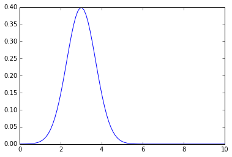

```python
xs = np.linspace(0, 10, 100)
m = 3
plt.plot(xs, gaussian_kernel(xs, m));
```

```python
def mean_shift(xs, kernel, x=None, niter=1000, tol=1e-6):
    """使用爬山法找出局部模式。"""
    if x is None:
        x = xs.mean()
    for i in range(niter):
        m = (kernel(xs, x)*xs).sum()/kernel(xs, x).sum() - x
        if np.sum(m**2) < tol:
            break
        x += m
    return i, x
```

```python
xs = np.concatenate([np.random.normal(-5, 1, 1000),
                     np.random.normal(0,2,1000),
                     np.random.normal(4, 1, 1000)])
```

```python
from functools import partial

kernel = gaussian_kernel
i1, m1 = mean_shift(xs, kernel, x=1, niter=1000, tol=1e-12)
i2, m2 = mean_shift(xs, kernel, x=-7, niter=1000, tol=1e-12)
i3, m3 = mean_shift(xs, kernel, x=7, niter=1000, tol=1e-12)
print i1, m1
print i2, m2
print i3, m3
```

```
161 0.307380887446
32 -4.89665274673
53 3.84321153311
```

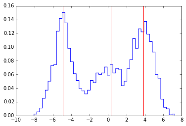

```python
import scipy.stats as stats
xp = np.linspace(0, 1.0, 100)
plt.hist(xs, 50, histtype='step', normed=True);
plt.axvline(m1, c='red')
plt.axvline(m2, c='red')
plt.axvline(m3, c='red')
```

```python
np.save('x1d.npy', xs)
```

## 归约和变换

并不需要特别多的算法，因为特定问题，在变换的帮助下，可能能够映射到一个已解决的问题。例如，广义线性模型可以归约到简单线性模型的框架，使用一种变换（“链接函数”）。图算法是另一个例子 -- 数量惊人的图问题可以归约为网络流问题，其中存在高效的算法。

## 蒙特卡罗方法

任何使用随机数生成器来寻找解的方法都是蒙特卡罗方法 -- 基本上所有统计学模拟都位于这个分类，包含重要性采样和 MCMC。同时，它常用于高维空间的数值积分，因为它们的复杂度只随样本数 $n$ 增大而增大，而不是维度 $d$。

### 寻找 $\pi$

```python
n = 1000000
pts = np.random.uniform(0,1,(n,2))
frac = np.sum(pts[:,0]**2 + pts[:,1]**2 < 1)/float(n)
print 4*frac
```

```
3.139952
```

## 参考

找零问题中关于记忆和动态规划用法的一篇[教程](http://interactivepython.org/courselib/static/pythonds/Recursion/DynamicProgramming.html)